# Multi-Row Headers

Lisa DeBruine

2021-10-17

```r
library(tidyverse)
library(readxl)
```

A student on our help forum once asked for help making a wide-format dataset long. When I tried to load the data, I realised the first three rows were all header rows. Here’s the code I wrote to deal with it.

First, I’ll make a small CSV “file” below. In a typical case, you’d read the data in from a file.

```r
demo_csv <- "SUB1, SUB1, SUB1, SUB1, SUB2, SUB2, SUB2, SUB2
COND1, COND1, COND2, COND2, COND1, COND1, COND2, COND2
X, Y, X, Y, X, Y, X, Y
10, 15, 6, 2, 42, 4, 32, 5
4, 43, 7, 34, 56, 43, 2, 33
77, 12, 14, 75, 36, 85, 3, 2"
```

If you try to read in this data, you’ll get a message about the duplicate column names and the resulting table will have “fixed” column headers and the next two columns headers as the first two rows.

```r
data <- read_csv(demo_csv)
```

| SUB1…1 | SUB1…2 | SUB1…3 | SUB1…4 | SUB2…5 | SUB2…6 | SUB2…7 | SUB2…8 |
| --- | --- | --- | --- | --- | --- | --- | --- |
| COND1 | COND1 | COND2 | COND2 | COND1 | COND1 | COND2 | COND2 |
| X | Y | X | Y | X | Y | X | Y |
| 10 | 15 | 6 | 2 | 42 | 4 | 32 | 5 |
| 4 | 43 | 7 | 34 | 56 | 43 | 2 | 33 |
| 77 | 12 | 14 | 75 | 36 | 85 | 3 | 2 |

Instead, you should read in just the header rows by setting `n_max` equal to the number of header rows and `col_names` to `FALSE`.

```r
data_head <- read_csv(demo_csv,
                      n_max = 3,
                      col_names = FALSE)
```

You will get a table that looks like this:

| X1 | X2 | X3 | X4 | X5 | X6 | X7 | X8 |
| --- | --- | --- | --- | --- | --- | --- | --- |
| SUB1 | SUB1 | SUB1 | SUB1 | SUB2 | SUB2 | SUB2 | SUB2 |
| COND1 | COND1 | COND2 | COND2 | COND1 | COND1 | COND2 | COND2 |
| X | Y | X | Y | X | Y | X | Y |

You can then make new header names by pasting together the names in the three rows by summarising across all the columns with the `paste()` function and collapsing them using "_". Use `unlist()` and `unname()` to convert the result from a table to a vector.

```r
new_names <- data_head %>%
  summarise(across(.fns = paste, collapse = "_")) %>%
  unlist() %>% unname()

new_names
```

```
## [1] "SUB1_COND1_X" "SUB1_COND1_Y" "SUB1_COND2_X" "SUB1_COND2_Y" "SUB2_COND1_X"
## [6] "SUB2_COND1_Y" "SUB2_COND2_X" "SUB2_COND2_Y"
```

Now you can read in the data without the three header rows. Use `skip` to skip the headers and set `col_names` to the new names.

```r
data <- read_csv(demo_csv,
                 skip = 3,
                 col_names = new_names,
                 show_col_types = FALSE)
```

| SUB1_COND1_X | SUB1_COND1_Y | SUB1_COND2_X | SUB1_COND2_Y | SUB2_COND1_X | SUB2_COND1_Y | SUB2_COND2_X | SUB2_COND2_Y |
| --- | --- | --- | --- | --- | --- | --- | --- |
| 10 | 15 | 6 | 2 | 42 | 4 | 32 | 5 |
| 4 | 43 | 7 | 34 | 56 | 43 | 2 | 33 |
| 77 | 12 | 14 | 75 | 36 | 85 | 3 | 2 |

If you have an excel file that merges the duplicate headers across rows, it’s a little trickier, but still do-able.

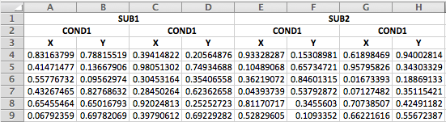

The first steps is the same: read in the first three rows.

```r
data_head <- read_excel("data/3headers_demo.xlsx",
                        n_max = 3,
                        col_names = FALSE)
```

| …1 | …2 | …3 | …4 | …5 | …6 | …7 | …8 |
| --- | --- | --- | --- | --- | --- | --- | --- |
| SUB1 | NA | NA | NA | SUB2 | NA | NA | NA |
| COND1 | NA | COND2 | NA | COND1 | NA | COND2 | NA |
| X | Y | X | Y | X | Y | X | Y |

The code below starts at the second column and fills in any missing data with the value in the previous column.

```r
for (i in 2:ncol(data_head)) {
  prev <- data_head[, i-1]
  this <- data_head[, i]
  missing <- is.na(this)
  this[missing, ] <- prev[missing, ]
  data_head[, i] <- this
}
```

Now you can continue generating the pasted name the same as above.

```r
new_names <- data_head %>%
  summarise(across(.fns = paste, collapse = "_")) %>%
  unlist() %>% unname()

new_names
```

```
## [1] "SUB1_COND1_X" "SUB1_COND1_Y" "SUB1_COND2_X" "SUB1_COND2_Y" "SUB2_COND1_X"
## [6] "SUB2_COND1_Y" "SUB2_COND2_X" "SUB2_COND2_Y"
```

If your data are set up with multiple headers, you’ll probably want to change the shape of the data. Here’s a quick example how to use `pivot_longer()` and `pivot_wider()` to do this with variable names like above.

```r
data <- read_excel("data/3headers_demo.xlsx",
                   skip = 3,
                   col_names = new_names)

data_long <- data %>%
  # add a row ID column if one doesn't exist already
  mutate(trial_id = row_number()) %>%
  # make a row for each data column
  pivot_longer(
    cols = -trial_id, # everything except trial_id
    names_to = c("sub_id", "condition", "coord"),
    names_sep = "_",
    values_to = "val"
  ) %>%
  # make x and y coord columns
  pivot_wider(
    names_from = coord,
    values_from = val
  )
```

| trial_id | sub_id | condition | X | Y |
| --- | --- | --- | --- | --- |
| 1 | SUB1 | COND1 | 0.8316380 | 0.7881552 |
| 1 | SUB1 | COND2 | 0.3941482 | 0.2056488 |
| 1 | SUB2 | COND1 | 0.9332829 | 0.1530898 |
| 1 | SUB2 | COND2 | 0.6189847 | 0.9400281 |
| 2 | SUB1 | COND1 | 0.4147148 | 0.1366791 |
| 2 | SUB1 | COND2 | 0.9805130 | 0.7493469 |
| 2 | SUB2 | COND1 | 0.1048907 | 0.6573472 |
| 2 | SUB2 | COND2 | 0.9579583 | 0.3430333 |
| 3 | SUB1 | COND1 | 0.5577673 | 0.0956297 |
| 3 | SUB1 | COND2 | 0.3045316 | 0.3540656 |
| 3 | SUB2 | COND1 | 0.3621907 | 0.8460132 |
| 3 | SUB2 | COND2 | 0.0167339 | 0.1886913 |
| 4 | SUB1 | COND1 | 0.4326746 | 0.8276863 |
| 4 | SUB1 | COND2 | 0.2845026 | 0.6236266 |
| 4 | SUB2 | COND1 | 0.0439374 | 0.5379287 |
| 4 | SUB2 | COND2 | 0.0712748 | 0.3511542 |
| 5 | SUB1 | COND1 | 0.6545546 | 0.6501679 |
| 5 | SUB1 | COND2 | 0.9202481 | 0.2525272 |
| 5 | SUB2 | COND1 | 0.8117072 | 0.3455603 |
| 5 | SUB2 | COND2 | 0.7073851 | 0.4249118 |
| 6 | SUB1 | COND1 | 0.0679236 | 0.6978207 |
| 6 | SUB1 | COND2 | 0.3979061 | 0.6922928 |
| 6 | SUB2 | COND1 | 0.5282960 | 0.1093352 |
| 6 | SUB2 | COND2 | 0.6622162 | 0.5567239 |